# Reproducible Research: Peer Assessment 1

## Introduction

Thisassignment is a brief analysis of the steps performed by an individual over two months measured at 5 minute intervals.

## Loading and preprocessing the data

```r
#Read the data & call libraries
if(!file.exists("activity.csv")){
unzip("activity.zip")
}
basedata = read.csv("activity.csv")
library(dplyr)
library(ggplot2)
```

```r
# Data transformation, total steps by date
newbase = basedata %>%
  group_by(date)%>%
  summarise(stepsbydate = sum(steps))
```

## What is mean total number of steps taken per day?

The average daily steps is 10,765, the histogram shows a distribution close to normal.

```r
summary(newbase$stepsbydate)
```

```
##    Min. 1st Qu.  Median    Mean 3rd Qu.    Max.    NA's
##      41    8841   10765   10766   13294   21194       8
```

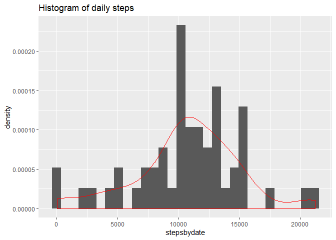

```r
ggplot(newbase, aes(stepsbydate))+
  geom_histogram(aes(y=..density..))+
  geom_density(col="red")+
  labs(title = "Histogram of daily steps")
```

## What is the average daily activity pattern?

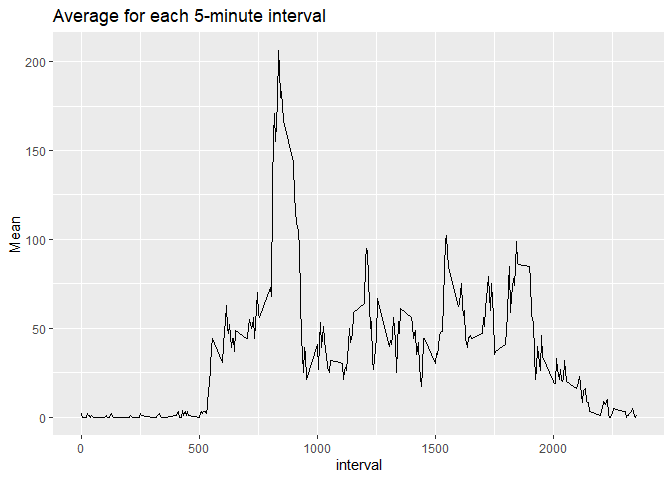

```r
MeanSteps = basedata  %>%
  filter(is.na(steps) == FALSE)%>%
  group_by(interval)%>%
  summarise(Mean = round(mean(steps),0))

ggplot(MeanSteps, aes(x=interval, y=Mean))+
  geom_line()+
  labs(title="Average for each 5-minute interval")
```

```r
knitr::kable(head(arrange(MeanSteps, desc(Mean)),n = 10), align = 'c',
             caption = "Top ten of steps in 5 minutes intervals")
```

Top ten of steps in 5 minutes intervals

| interval | Mean |
| --- | --- |
| 835 | 206 |
| 840 | 196 |
| 850 | 183 |
| 845 | 180 |
| 830 | 177 |
| 820 | 171 |
| 855 | 167 |
| 815 | 158 |
| 825 | 155 |
| 900 | 143 |

## Imputing missing values

The *‘missing values’* will be replaced by the average values for the corresponding five-minute interval, this is achieved first by calculating said average, and then substitute each missing value in the base.

```r
# Calculate the average for each 5-minute interval

basedataNA = basedata %>%
  group_by(interval)%>%
  mutate(newsteps = mean(steps, na.rm=TRUE))

# This part replaces the NAs by the average of the corresponding five-minute interval.

for (i in 1:length(basedataNA$newsteps)) {
  if (is.na(basedataNA$steps[i])==TRUE) {
    basedataNA$steps[i] <- basedataNA$newsteps[i]
  }

}
```

### Make a histogram of the total number of steps taken each day and Calculate and report the mean and median total number of steps taken per day.

In this case, the distribution is clearly more focused on the mean and in effect there is no difference between the mean and the median.

```r
newbaseNA = basedataNA %>%
  group_by(date)%>%
  summarise(stepsbydate = sum(steps))

summary(newbaseNA$stepsbydate)
```

```
##    Min. 1st Qu.  Median    Mean 3rd Qu.    Max.
##      41    9819   10766   10766   12811   21194
```

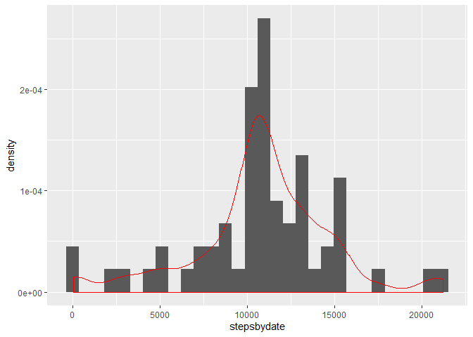

```r
ggplot(newbaseNA, aes(stepsbydate))+
  geom_histogram(aes(y=..density..))+
  geom_density(col="red")
```

## Are there differences in activity patterns between weekdays and weekends?

The graph shows the average differences from weekends. During Saturday and Sunday the morning activity clearly decreases and on the other hand, in the daytime periods there is more activity on the weekends.

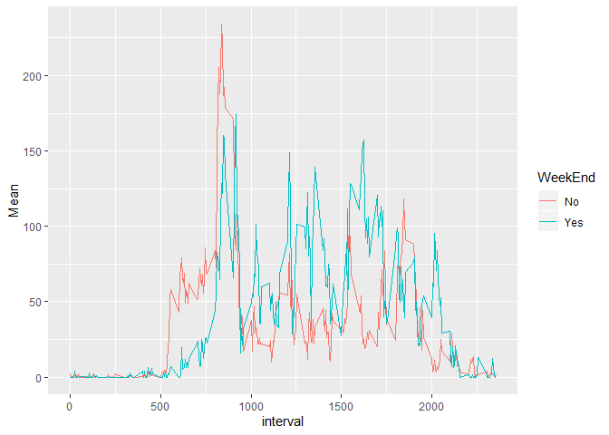

```r
basedata$date <- as.Date(basedata$date)
basedata$DoW <- weekdays(basedata$date)
basedata$WeekEnd = "No"
basedata$WeekEnd[basedata$DoW == "sábado" | basedata$DoW=="domingo"] = "Yes"

MeanStepsNA = basedata  %>%
  filter(is.na(steps) == FALSE)%>%
  group_by(interval, WeekEnd)%>%
  summarise(Mean = mean(steps))

ggplot(MeanStepsNA, aes(x=interval, y=Mean))+
  geom_line(aes(col=WeekEnd))
```